# TrIdent Tutorial

#### Default:

Search all contigs classified as Prophage-like for specialized transduction:

```r
Specialized_transduction <- SpecializedTransduction_ID(VLP_pileup=VLPFraction_sampledata, transductionclassifications=TrIdent_results, noreadcov=500, spectranslength=2000, cleanup=TRUE)
## 2 contigs have potential specialized transduction
```

When you search all contigs, the output of `SpecializedTransduction_ID()` will be a list. The first object contains a summary table for the specialized transduction search results:

```r
SpecializedTransduction_summary_table <- Specialized_transduction$Summary_table
```

| ref_name | Specialized_transduction | Left | Right | Length_left | Length_right |
| --- | --- | --- | --- | --- | --- |
| NODE_44 | yes | yes | no | 2700 | NA |
| NODE_62 | yes | yes | no | 45300 | NA |
| NODE_125 | no | no | no | NA | NA |
| NODE_368 | no | no | no | NA | NA |

The second object in the output-list contains another list with the resulting **log 10** read coverage plots for all contigs classified as Prophage-like. The coverages are put in log-scale to help users visualize specialized transduction patterns as they are sometimes too low frequency to be seen with raw coverages alone. Additionally, the plots are ‘zoomed-in’ on the Prophage-like pattern to further aid with specialized transduction visualization. The borders of the prophage/PICI as identified by `SpecializedTransduction_ID()` are marked on each plot with a black vertical line. If `SpecializedTransduction_ID()` identifies potential specialized transduction, it will color the plot green whereas if it does not identify specialized transduction, it will color the plot blue. The end of specialized transduction as determined by `SpecializedTransduction_ID()` will be marked with a red vertical line. Each plot is named by the associated contig accession and can be saved as a `ggplot` object for further manipulation by the user.

View all the plots:

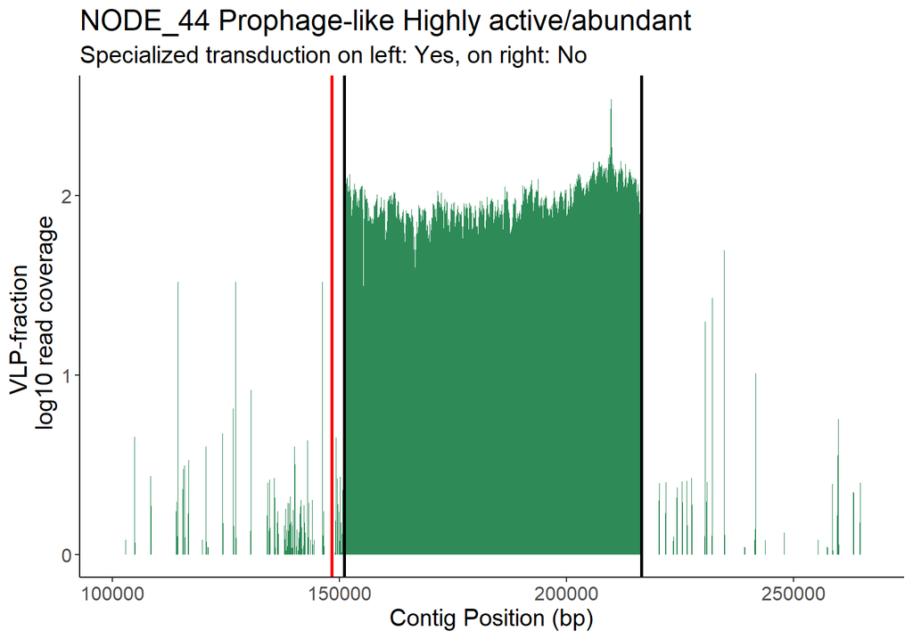

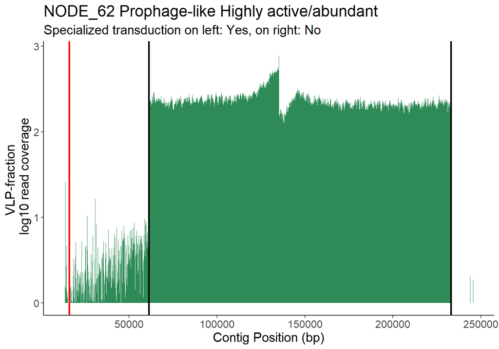

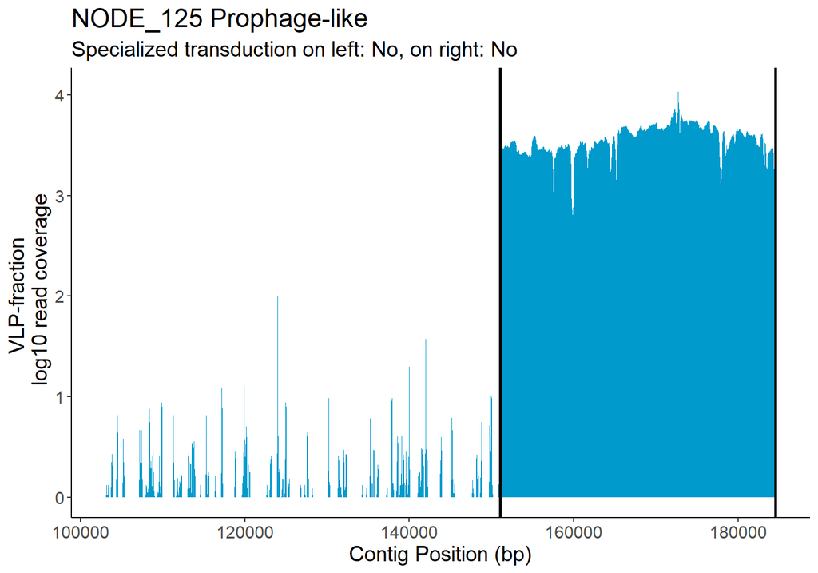

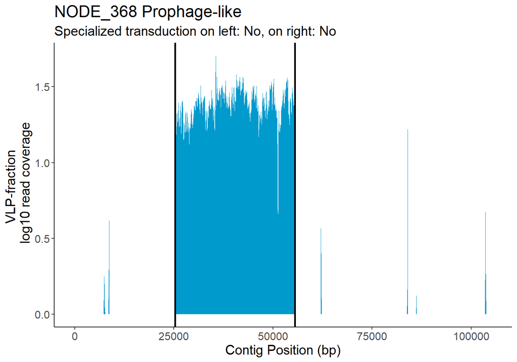

```r
Specialized_transduction$Plots
```

View a specific plot:

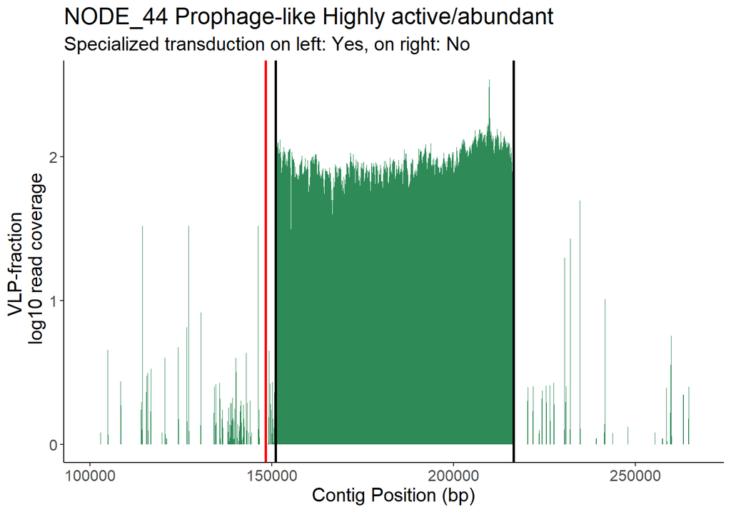

```r
Specialized_transduction$Plots$NODE_44
```

If desired, the user can also search a single contig for specialized transduction by specifying the contig’s reference name with the `specificcontig` parameter:

```r
Specialized_transduction_NODE44 <- SpecializedTransduction_ID(VLP_pileup=VLPFraction_sampledata, transductionclassifications=TrIdent_results, specificcontig="NODE_44", noreadcov=500, spectranslength=2000, cleanup=TRUE)
```

### Create final summary table:

If you’d like to combine the summary tables produced by `TrIdent_Classifier()` and `SpecializedTransduction_ID()`, try the following code:

```r
Final_TrIdentSummaryTable <- merge(TrIdent_summary_table, SpecializedTransduction_summary_table, by="ref_name", all.x=TRUE)
```

| ref_name | classifications | NormMatchScore | match_size | start_pos | stop_pos | active_prophage | elevation_ratio | slope | Specialized_transduction | Left | Right | Length_left | Length_right |
| --- | --- | --- | --- | --- | --- | --- | --- | --- | --- | --- | --- | --- | --- |
| NODE_1088 | HighCoverageNoPattern | 0.08964437 | NA | NA | NA | NA | NA | NA | NA | NA | NA | NA | NA |
| NODE_125 | Prophage-like | 0.23903635 | 31000 | 153000 | 184000 | NO | 1.1175 | NA | no | no | no | NA | NA |
| NODE_238 | Sloping | 0.14225027 | 146000 | 1000 | 147000 | NA | NA | -0.2060 | NA | NA | NA | NA | NA |
| NODE_25 | InsufficientCoverage | NA | NA | NA | NA | NA | NA | NA | NA | NA | NA | NA | NA |
| NODE_251 | Sloping | 0.11734790 | 144000 | 1000 | 145000 | NA | NA | 0.0524 | NA | NA | NA | NA | NA |
| NODE_368 | Prophage-like | 0.16050720 | 28000 | 27000 | 55000 | MIXED | 0.3986 | NA | no | no | no | NA | NA |
| NODE_44 | Prophage-like | 0.19117212 | 65000 | 151000 | 216000 | YES | 1.3657 | NA | yes | yes | no | 2700 | NA |
| NODE_560 | HighCoverageNoPattern | 0.07094737 | NA | NA | NA | NA | NA | NA | NA | NA | NA | NA | NA |
| NODE_62 | Prophage-like | 0.14338316 | 171000 | 63000 | 234000 | YES | 1.4700 | NA | yes | yes | no | 45300 | NA |